# M215_Proj_Draft

#### Data Exploration and Visualization

- Age

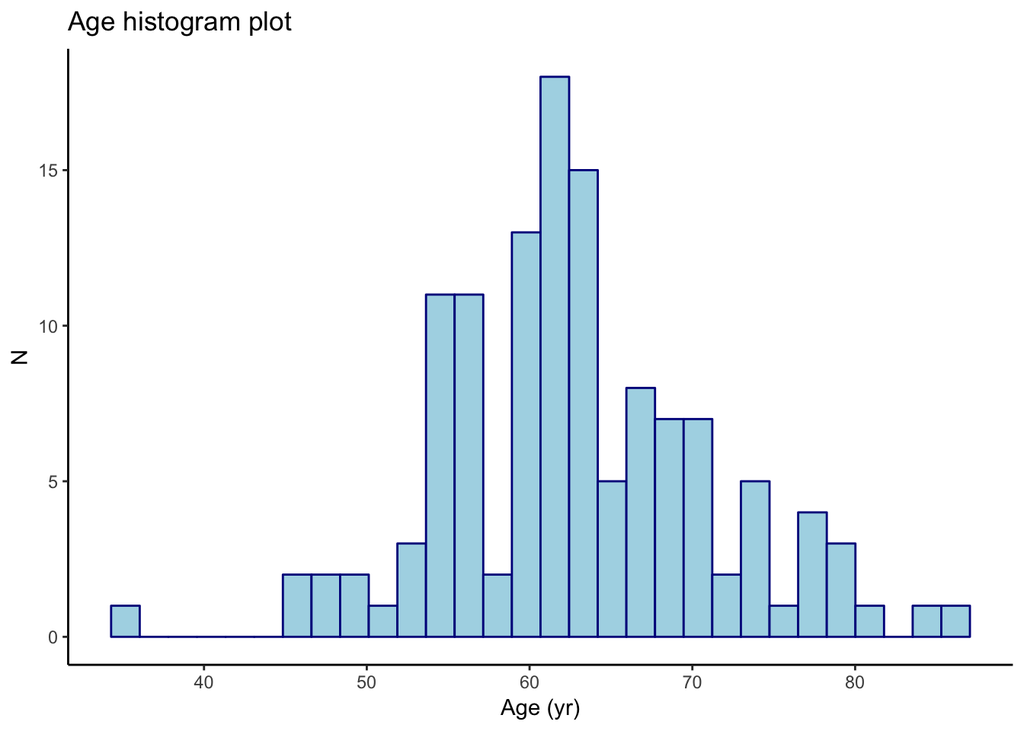

```r
# Age histogram
ec.data %>% filter(!is.na(ha.age)) %>%
  ggplot(aes(x=ha.age)) +
  geom_histogram(color="darkblue", fill="lightblue") +
  labs(title="Age histogram plot",x="Age (yr)", y = "N") +
  theme_classic()
```

```r
# Almost all patients are older than  40. Majority are from 55 to 70
```

- Fractional-shortening

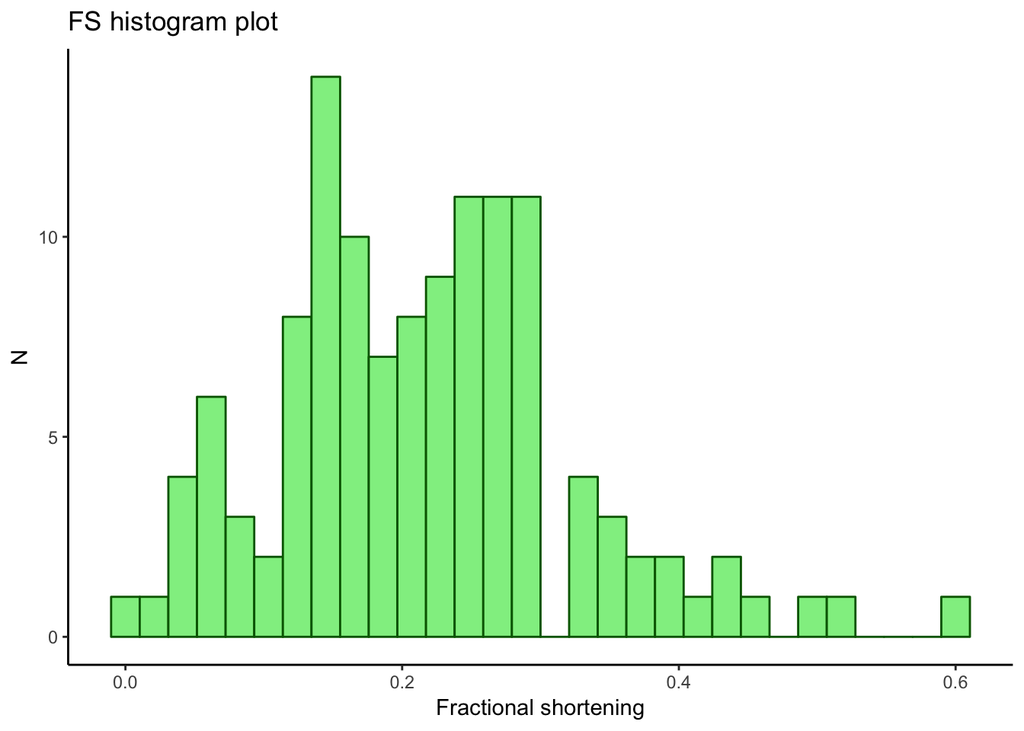

```r
# fractional-shortening
ec.data %>% filter(!is.na(fs)) %>%
  ggplot(aes(x=fs)) +
  geom_histogram(color="darkgreen", fill="lightgreen") +
  labs(title="FS histogram plot",x='Fractional shortening', y = "N") +
  theme_classic()
```

```r
# Normal range is 25-45%, Mild is 20-25%, Moderate is 15-20%, and Severe is <15%
# Convert the FS to categorical variable 1:normal, 0:abnormal
ec.data <- ec.data %>% mutate(fs.cat = ifelse(fs > 0.25, 1, 0))

ec.data <- ec.data %>% mutate(fs.cat.2 = case_when(fs <= 0.25  ~ 'Abnormal',
                                      fs > 0.25 ~ 'Nomal'))
```

- Left ventricular wall motion score index: The shortening fraction reflects the left ventricle systolic function

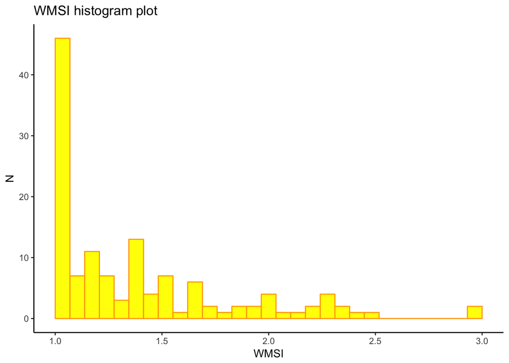

```r
# Left ventricular wall motion score index (WMSI), defined as the average wall motion score of 17 myocardial segments (1 = normal, 2 = hypokinetic, 3 = akinetic, 4 = dyskinetic scored for each segment) was assessed at all 3 stages of stress.

ec.data %>% filter(!is.na(wm.index)) %>%
  ggplot(aes(x=wm.index)) +
  geom_histogram(color="orange", fill="yellow") +
  labs(title="WMSI histogram plot",x='WMSI', y = "N") +
  theme_classic()
```

```r
ec.data <- ec.data %>% mutate(wmsi = ifelse(wm.index <= 1.25, 1, 0))
# 1: normal, 0: hypokinetic, akinetic
```

- left ventricular end-diastolic dimension. This is a measure of the size of the heart at end-diastole.

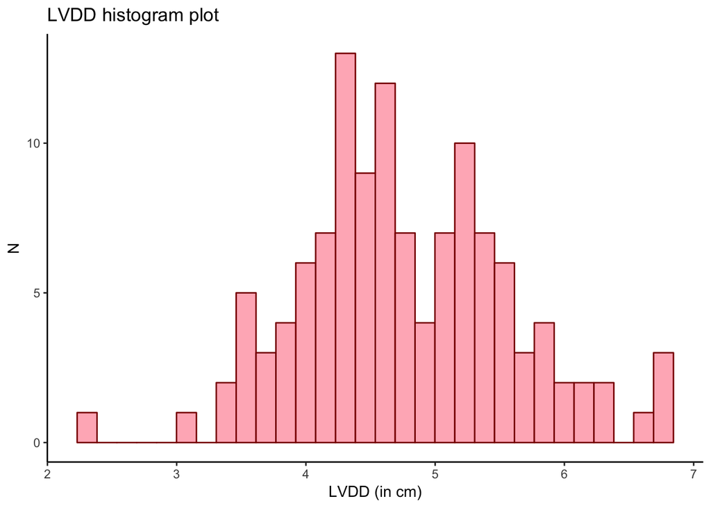

```r
ec.data %>% filter(!is.na(lvdd)) %>%
  ggplot(aes(x=lvdd)) +
  geom_histogram(color="darkred", fill="lightpink") +
  labs(title="LVDD histogram plot",x='LVDD (in cm)', y = "N") +
  theme_classic()
```

```r
ec.data <- ec.data %>% mutate(lvdd.cat = ifelse(lvdd<= 5.0, 1, 0))
```

3. Fit model

### a) Non-parametric methods

#### Kaplan-Meier estimator

- For survival data one commonly wants to find an estimate of the survival function S(t). The standard estimator of S(t) is the Kaplan-Meier estimator. Kaplan-Meier estimator is nonparametric, which requires no parametric assumptions.

```r
fit.km <- survfit(Surv(survival, death) ~ 1, data = ec.data)
summary(fit.km)
```

```
## Call: survfit(formula = Surv(survival, death) ~ 1, data = ec.data)
##
## 1 observation deleted due to missingness
##  time n.risk n.event survival std.err lower 95% CI upper 95% CI
##     9     97       1   0.9897  0.0103      0.96979       1.0000
##    10     96       2   0.9691  0.0176      0.93523       1.0000
##    11     93       1   0.9587  0.0202      0.91979       0.9992
##    12     92       4   0.9170  0.0281      0.86349       0.9738
##    13     88       2   0.8961  0.0311      0.83721       0.9592
##    15     86       1   0.8857  0.0324      0.82437       0.9516
##    16     84       3   0.8541  0.0361      0.78626       0.9277
##    17     81       2   0.8330  0.0381      0.76152       0.9112
##    19     79       3   0.8014  0.0408      0.72522       0.8855
##    20     74       1   0.7905  0.0417      0.71292       0.8766
##    21     72       1   0.7795  0.0425      0.70051       0.8675
```

[output cut: 29 more lines]

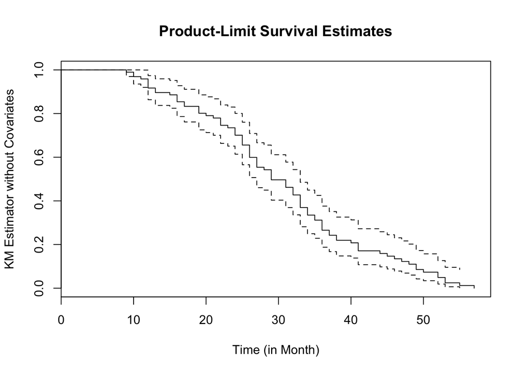

```r
# Plotting the Kaplan-Meier Estimates
plot(fit.km, main = 'Product-Limit Survival Estimates',
ylab = 'KM Estimator without Covariates', xlab = 'Time (in Month)')
```

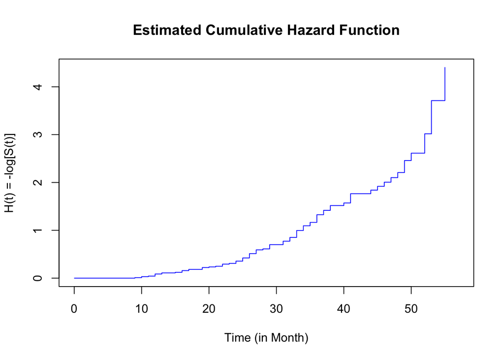

```r
# Plotting -log[S(t)] vs. t
plot(-log(fit.km$surv) ~ fit.km$time, type = 's', col = 'blue',
     main = 'Estimated Cumulative Hazard Function', ylab = 'H(t) = -log[S(t)]',
     xlab = 'Time (in Month)')
```

* The median is **29**.

#### Nelson-Aalen Estimator

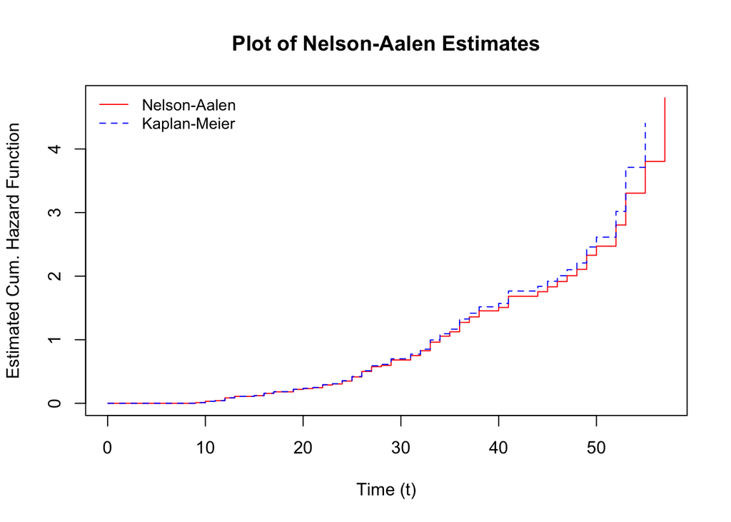

```r
H.km <- -log(fit.km$surv)
#Nelson-Aalen Estimate of H(t):
h <- fit.km$n.event/fit.km$n.risk
H.na <- cumsum(h) #Nelson-Aalen estimates
s <- fit.km$n.event/fit.km$n.risk^2
V.na <- cumsum(s) #Variance estimate for the N-A estimator
NAest <- cbind(H.na, sqrt(V.na))
colnames(NAest) <- c("NA-Est.","Std. Err")

#Plot of the Nelson-Aalen Estimate
plot(H.na ~ fit.km$time, type = 's',
     main="Plot of Nelson-Aalen Estimates", xlab="Time (t)",
     ylab="Estimated Cum. Hazard Function", col = "red")
lines(-log(fit.km$surv) ~ fit.km$time, type = "s", lty = 2, col = "blue")
legend("topleft", c( "Nelson-Aalen","Kaplan-Meier"), lty = 1:2,
col = c("red", "blue"), bty = "n", cex = .9)
```

```r
# plot(-log(fit.km$surv) ~ fit.km$time, type = 's', col = 'blue',
#      main = 'Estimated Cumulative Hazard Function', ylab = 'H(t) = -log[S(t)]',
#      xlab = 'Time (in Month)')
```

#### Comparing the Nelson-Aalen Estimate to the Kaplan-Meier Estimate

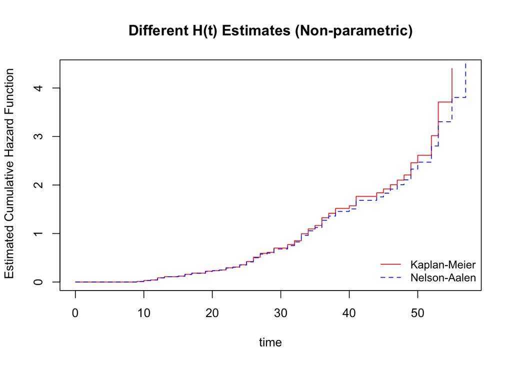

```r
plot(H.km~fit.km$time, xlab = "time", ylab = " Estimated Cumulative Hazard Function",
     main = "Different H(t) Estimates (Non-parametric)", type = "s", col = "red")
lines(H.na~fit.km$time, type = "s", lty = 2, col = "blue")
legend("bottomright", c("Kaplan-Meier", "Nelson-Aalen"), lty = 1:2,
col = c("red", "blue"), bty = "n", cex = .9)
```